# **Case QuantumFinance - Disciplina NLP - Classificador de chamados**

**Atenção:**

- Leia com atenção o descritivo do trabalho e as orientações do template.
- O trabalho deve ser entregue respeitando a estrutura do arquivo de template em notebook "Template_Trabalho_Final_NLP.ipynb" e compactado no formato .zip. Apenas um arquivo no formato .ipynb deve ser entregue consolidando todo o trabalho.

**Participantes (RM - NOME):**  
xxxx - xxxxx  
xxxx - xxxxx  
xxxx - xxxxx  
xxxx - xxxxx

### **Crie um classificador de chamados aplicando técnicas de PLN**

A **QuantumFinance** tem um canal de atendimento via chat e precisar classificar os assuntos dos atendimentos para melhorar as tratativas dos chamados dos clientes. O canal recebe textos abertos dos clientes relatando o problema e/ou dúvida e depois é direcionado para alguma área especialista no assunto para uma melhor tratativa.

1. Crie ao menos um modelo classificador de assuntos aplicando técnicas de NLP (PLN), Vetorização (n-grama + métrica) e modelo supervisionado, que consiga classificar através de um texto o assunto conforme disponível na base de dados [1] para treinamento e validação do seu modelo.

O modelo precisar atingir um score na **métrica F1 Score superior a 75%**. Utilize o dataset [1] para treinar e testar o modelo, separe o dataset em duas amostras (75% para treinamento e 25% para teste com o randon_state igual a 42).

2. Utilizar ao menos uma aplicação de modelos com Embeddings usando Word2Vec e/ou LLM´s para criar o modelo classificador com os critérios do item 1. Não é necessário implementar aplicações usando serviços de API da OpenAI ou outros por exemplo.

Fique à vontade para testar e explorar as técnicas de pré-processamento, abordagens de NLP, algoritmos e bibliotecas, mas explique e justifique as suas decisões durante o desenvolvimento.

**Composição da nota:**

**50%** - Demonstrações das aplicações das técnicas de PLN (regras, pré-processamentos, tratamentos, variedade de modelos aplicados, aplicações de GenIA, organização do pipeline, etc.)

**50%** - Baseado na performance (score) obtida com a amostra de teste no pipeline do modelo campeão (validar com a Métrica F1 Score). **Separar o pipeline completo do modelo campeão conforme template.**

O trabalho poderá ser feito em grupo de 2 até 4 pessoas (mesmo grupo do Startup One) e trabalhos iguais serão descontado nota e passível de reprovação.

**[1] = https://dados-ml-pln.s3.sa-east-1.amazonaws.com/tickets_reclamacoes_classificados.csv**

**[F1 Score](https://scikit-learn.org/stable/modules/generated/sklearn.metrics.f1_score.html)** com average='weighted'

```python
# CARREGANDO O DATA FRAME
import pandas as pd
#df = pd.read_csv('https://dados-ml-pln.s3.sa-east-1.amazonaws.com/tickets_reclamacoes_classificados.csv', delimiter=';')

# Façam o download do arquivo e utilizem localmente durante os testes
df = pd.read_csv('tickets_reclamacoes_classificados.csv', delimiter = ';')
```

```python
df.info()
```

```
<class 'pandas.core.frame.DataFrame'>
RangeIndex: 21072 entries, 0 to 21071
Data columns (total 4 columns):
 #   Column                Non-Null Count  Dtype
---  ------                --------------  -----
 0   id_reclamacao         21072 non-null  int64
 1   data_abertura         21072 non-null  object
 2   categoria             21072 non-null  object
 3   descricao_reclamacao  21072 non-null  object
dtypes: int64(1), object(3)
memory usage: 658.6+ KB
```

Bom desenvolvimento!

### **Area de desenvolvimento e validações**

Faça aqui as demonstrações das aplicações das técnicas de PLN (regras, pré-processamentos, tratamentos, variedade de modelos aplicados, organização do pipeline, etc.)

Fique à vontade para testar e explorar as técnicas de pré-processamento, abordagens de NLP, algoritmos e bibliotecas, mas explique e justifique as suas decisões durante o desenvolvimento.

```python
print(f"Dataset carregado: {df.shape[0]} registros e {df.shape[1]} colunas")
df.head()
```

```
Dataset carregado: 21072 registros e 4 colunas
```

|  | id_reclamacao | data_abertura | categoria | descricao_reclamacao |
| --- | --- | --- | --- | --- |
| 0 | 3229299 | 2019-05-01T12:00:00-05:00 | Hipotecas / Empréstimos | Bom dia, meu nome é xxxx xxxx e agradeço se vo... |
| 1 | 3199379 | 2019-04-02T12:00:00-05:00 | Cartão de crédito / Cartão pré-pago | Atualizei meu cartão xxxx xxxx em xx/xx/2018 e... |
| 2 | 3233499 | 2019-05-06T12:00:00-05:00 | Cartão de crédito / Cartão pré-pago | O cartão Chase foi relatado em xx/xx/2019. No ... |
| 3 | 3180294 | 2019-03-14T12:00:00-05:00 | Cartão de crédito / Cartão pré-pago | Em xx/xx/2018, enquanto tentava reservar um ti... |
| 4 | 3224980 | 2019-04-27T12:00:00-05:00 | Serviços de conta bancária | Meu neto me dê cheque por {$ 1600,00} Eu depos... |

## **Análise Exploratória dos Dados (EDA)**

Verificação: vocabulário, nulos e validar se há termos representativos por categoria.

A análise de **frequência das classes**, **comprimento médio** e **n-grams mais frequentes** confirma se bigramas ajudam a capturar contexto (ex: "cartão bloqueado", "empréstimo negado").

Detectar **palavras de domínio** que podem virar stopwords personalizadas (ex: "reclamação", "cliente")

```python
# Verificação de valores nulos
print("=== Valores Nulos ===")
print(df.isnull().sum())
print(f"\nTotal de nulos: {df.isnull().sum().sum()}")

# Verificação de duplicados
print(f"\n=== Duplicados ===")
print(f"Registros duplicados: {df.duplicated().sum()}")

# Verificação de textos vazios
print(f"\n=== Textos Vazios ===")
textos_vazios = df['descricao_reclamacao'].str.strip().str.len() == 0
print(f"Textos vazios: {textos_vazios.sum()}")
```

```
=== Valores Nulos ===
id_reclamacao           0
data_abertura           0
categoria               0
descricao_reclamacao    0
dtype: int64

Total de nulos: 0

=== Duplicados ===
Registros duplicados: 0

=== Textos Vazios ===
Textos vazios: 0
```

```
=== Distribuição de Categorias ===
                                     Quantidade  Percentual (%)
categoria
Serviços de conta bancária                 5161           24.49
Cartão de crédito / Cartão pré-pago        5006           23.76
Roubo / Relatório de disputa               4822           22.88
Hipotecas / Empréstimos                    3850           18.27
Outros                                     2233           10.60
```

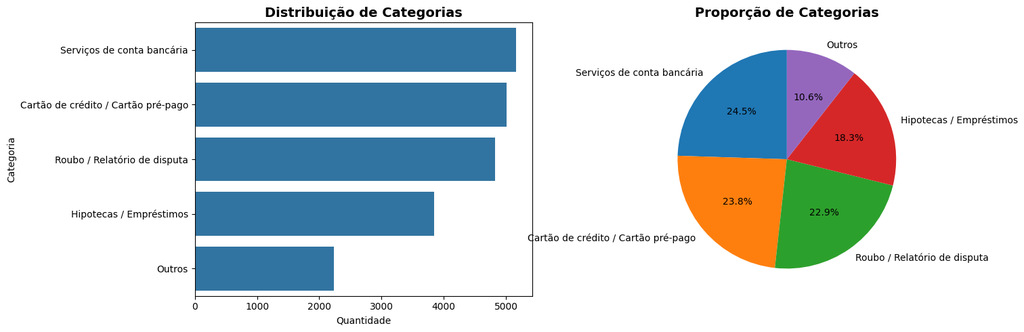

```
Análise: As classes apresentam leve desbalanceamento — variando de cerca de 10% a 24% dos registros —, mas ainda mantêm proporções suficientemente próximas para um treinamento supervisionado estável.
```

```python
import numpy as np
import matplotlib.pyplot as plt
import seaborn as sns
# Contagem e percentual de cada categoria
print("=== Distribuição de Categorias ===")
categoria_counts = df['categoria'].value_counts()
categoria_percent = df['categoria'].value_counts(normalize=True) * 100

distribuicao = pd.DataFrame({
    'Quantidade': categoria_counts,
    'Percentual (%)': categoria_percent.round(2)
})
print(distribuicao)

# Visualização
fig, axes = plt.subplots(1, 2, figsize=(15, 5))

# Gráfico de barras
sns.countplot(data=df, y='categoria', order=categoria_counts.index, ax=axes[0])
axes[0].set_title('Distribuição de Categorias', fontsize=14, fontweight='bold')
axes[0].set_xlabel('Quantidade')
axes[0].set_ylabel('Categoria')

# Gráfico de pizza
axes[1].pie(categoria_counts, labels=categoria_counts.index, autopct='%1.1f%%', startangle=90)
axes[1].set_title('Proporção de Categorias', fontsize=14, fontweight='bold')

plt.tight_layout()
plt.show()

print("\nAnálise: As classes apresentam leve desbalanceamento — variando de cerca de 10% a 24% dos registros —, mas ainda mantêm proporções suficientemente próximas para um treinamento supervisionado estável.")
```

```
=== Estatísticas de Comprimento dos Textos ===

Caracteres:
count    21072.000000
mean      1465.305429
std       1585.890511
min          9.000000
25%        560.000000
50%       1041.000000
75%       1843.250000
max      33897.000000
Name: num_caracteres, dtype: float64

Palavras:
count    21072.000000
mean       247.782413
std        265.400668
min          2.000000
25%         95.000000
50%        177.000000
75%        312.250000
max       5536.000000
Name: num_palavras, dtype: float64
```

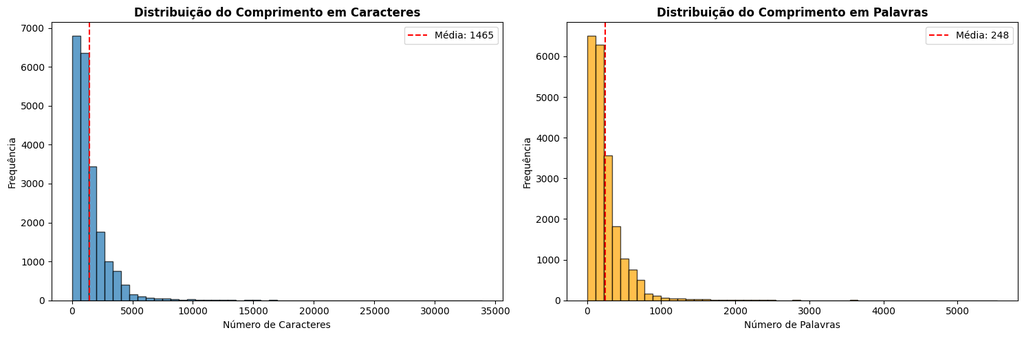

```
✓ Análise: Os textos são longos (média ~250 palavras), contendo narrativas completas. O pré-processamento deve reduzir ruído e redundância sem eliminar palavras relevantes do domínio financeiro.
```

```python
# Análise de comprimento em caracteres e palavras
df['num_caracteres'] = df['descricao_reclamacao'].str.len()
df['num_palavras'] = df['descricao_reclamacao'].str.split().str.len()

print("=== Estatísticas de Comprimento dos Textos ===")
print("\nCaracteres:")
print(df['num_caracteres'].describe())
print("\nPalavras:")
print(df['num_palavras'].describe())

# Visualização
fig, axes = plt.subplots(1, 2, figsize=(15, 5))

# Histograma de caracteres
axes[0].hist(df['num_caracteres'], bins=50, edgecolor='black', alpha=0.7)
axes[0].set_title('Distribuição do Comprimento em Caracteres', fontsize=12, fontweight='bold')
axes[0].set_xlabel('Número de Caracteres')
axes[0].set_ylabel('Frequência')
axes[0].axvline(df['num_caracteres'].mean(), color='red', linestyle='--', label=f'Média: {df["num_caracteres"].mean():.0f}')
axes[0].legend()

# Histograma de palavras
axes[1].hist(df['num_palavras'], bins=50, edgecolor='black', alpha=0.7, color='orange')
axes[1].set_title('Distribuição do Comprimento em Palavras', fontsize=12, fontweight='bold')
axes[1].set_xlabel('Número de Palavras')
axes[1].set_ylabel('Frequência')
axes[1].axvline(df['num_palavras'].mean(), color='red', linestyle='--', label=f'Média: {df["num_palavras"].mean():.0f}')
axes[1].legend()

plt.tight_layout()
plt.show()

print("\n✓ Análise: Os textos são longos (média ~250 palavras), contendo narrativas completas. O pré-processamento deve reduzir ruído e redundância sem eliminar palavras relevantes do domínio financeiro.")
```

```python
import nltk
from nltk.corpus import stopwords
from sklearn.feature_extraction.text import CountVectorizer

# Download de recursos necessários do NLTK
nltk.download('stopwords', quiet=True)
nltk.download('rslp', quiet=True)
nltk.download('punkt', quiet=True)


# Stopwords customizadas baseadas na EDA
custom_stopwords = [
    'cliente', 'favor', 'gostaria', 'solicito', 'peço', 'preciso',
    'reclamação', 'reclamações', 'problema', 'problemas',
    'situação', 'situações', 'caso', 'casos',
    'informação', 'informações', 'dados', 'dado',
    'atendimento', 'atendimentos', 'contato', 'contatos',
    'serviço', 'serviços'
]

# Adicionar stopwords em inglês leve
stopwords_en_light = ['the', 'and', 'or', 'but', 'in', 'on', 'at', 'to', 'for', 'of', 'with', 'by']

# Combinar todas as stopwords em uma LISTA
stop_words_pt = list(stopwords.words('portuguese')) + custom_stopwords + stopwords_en_light

# Converter para lista única (remover duplicatas)
stop_words_pt = list(set(stop_words_pt))
# Função para extrair n-gramas mais frequentes
def get_top_ngrams(corpus, n=1, top=20, use_stopwords=False):
    """
    Extrai os n-gramas mais frequentes do corpus

    Parâmetros:
    - corpus: lista de textos
    - n: tamanho do n-grama (1=unigrama, 2=bigrama)
    - top: quantidade de n-gramas a retornar
    - use_stopwords: se True, remove stopwords
    """


    stop_words = stop_words_pt if use_stopwords else None

    vec = CountVectorizer(
        ngram_range=(n, n),
        max_features=top,
        stop_words=stop_words,
        lowercase=True
    ).fit(corpus)

    bag_of_words = vec.transform(corpus)
    sum_words = bag_of_words.sum(axis=0)
    words_freq = [(word, sum_words[0, idx]) for word, idx in vec.vocabulary_.items()]
    words_freq = sorted(words_freq, key=lambda x: x[1], reverse=True)

    return pd.DataFrame(words_freq, columns=['ngrama', 'frequencia'])

# Extrair unigramas e bigramas
print("=== Top 20 Unigramas (SEM remoção de stopwords) ===")
top_unigrams = get_top_ngrams(df['descricao_reclamacao'], n=1, top=20, use_stopwords=False)
print(top_unigrams)

print("\n=== Top 20 Unigramas (COM remoção de stopwords) ===")
top_unigrams_clean = get_top_ngrams(df['descricao_reclamacao'], n=1, top=20, use_stopwords=True)
print(top_unigrams_clean)

print("\n=== Top 20 Bigramas (COM remoção de stopwords) ===")
top_bigrams = get_top_ngrams(df['descricao_reclamacao'], n=2, top=20, use_stopwords=True)
print(top_bigrams)
```

```
=== Top 20 Unigramas (SEM remoção de stopwords) ===
   ngrama  frequencia
0      de      235401
1    xxxx      225465
2     que      182265
3    para      102172
4     não       86254
5      em       83908
6      xx       76729
7   chase       67876
8      eu       64006
9      um       63753
10    uma       59844
11    com       56620
12     do       51296
```

[output cut: 53 more lines]

```python
# IMPLEMENTAÇÃO: Função de limpeza de tokens mascarados
import re

def clean_text(text):
    """
    Remove tokens mascarados específicos do domínio financeiro

    Parâmetros:
    - text: texto a ser limpo

    Retorna:
    - texto limpo sem tokens mascarados
    """
    if not isinstance(text, str):
        return ""

    # Converter para lowercase
    text = text.lower()

    # Remover tokens mascarados
    text = re.sub(r'\b[xX]{2,}\b', '', text)  # Remove xxxx, xx
    text = re.sub(r'\b\d{2,}\b', '', text)     # Remove 00, 2020, etc.

    # Limpar espaços extras
    text = re.sub(r'\s+', ' ', text).strip()

    return text

# Teste da função
texto_teste = "Eu xxxx meu cartão xx foi bloqueado 00 e preciso de ajuda"
print("Teste da função:")
print(f"Original: {texto_teste}")
print(f"Limpo: {clean_text(texto_teste)}")
```

```
Teste da função:
Original: Eu xxxx meu cartão xx foi bloqueado 00 e preciso de ajuda
Limpo: eu meu cartão foi bloqueado e preciso de ajuda
```